# R Notebook

1 Introduction Let’s practice drawing and analysing sampling distributions from a larger dataset that we will treat as a population. Slightly morbidly, we’re going to use data derived from a study of heart disease!

Remember throughout the following tasks that this is something of a ‘fake’ situation: Normally, we would have a single sample of a given size drawn from a population, ideally containing as much data as possible. Here, we’re treating a sample as if it were a population, and repeatedly drawing smaller samples from it. We’re doing this for educational purposes, to let you see what would happen if you could sample a population multiple times.

2 MVP Load and explore the data held in heart.csv. A data dictionary is also available.

```r
library(tidyverse)
library(infer)

heart <- read_csv("data/heart.csv")
```

Plot a histogram and/or boxplot for thalach (maximum heart rate achieved in stress testing). How normal is the distribution?

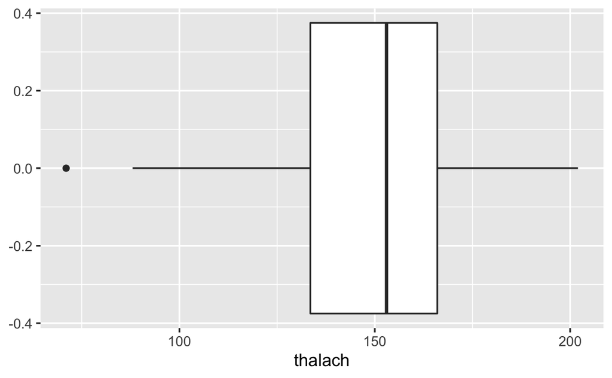

1 outlier, median just over 150, left skewed

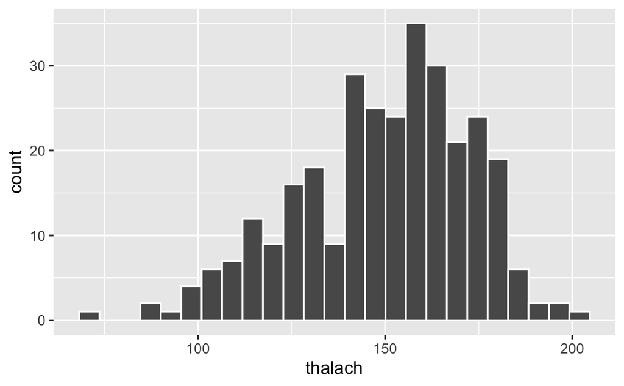

```r
heart %>%
  ggplot() +
  aes(x = thalach) +
  geom_histogram(col = "white", bins = 25)
```

Also plot a barplot of exang (whether the patient displayed exercise induced angina)

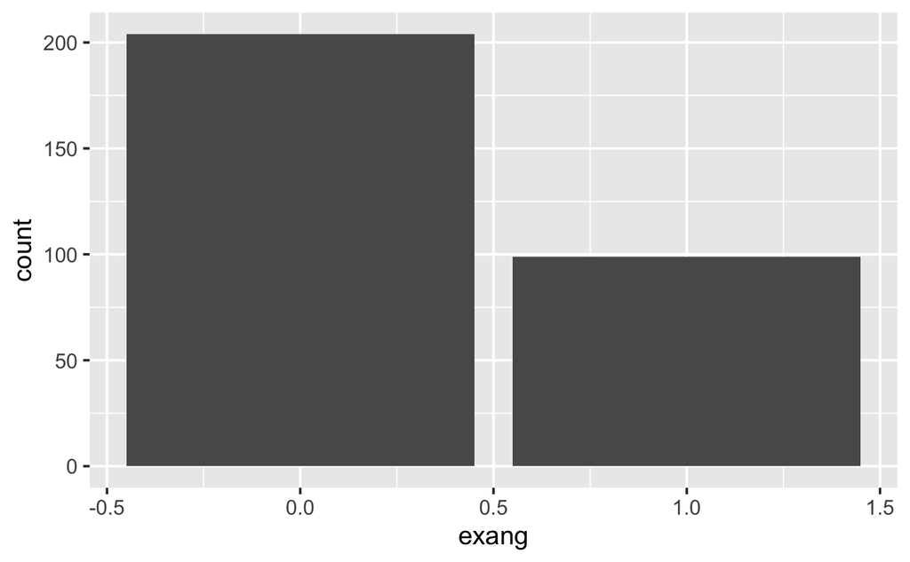

```r
heart %>%
  ggplot(aes(x = exang)) +
  geom_bar()
```

exang of 0 roughly twice as likely as exang of 1. Assume 1 = experienced exang and 0 = no exang reported

Now calculate population parameters: what is the mean thalach in the population. What proportion of patients have exercise induced angina (exang)?

| mean_thalach | prop_exang |
| --- | --- |
| 149.6469 | 0.3267327 |

Now take a single sample of 50-patients from the population and calculate point estimates for mean thalach and proportion of exang from this sample (let’s call these mean_thalach and prop_exang going forward). [Hint - use rep_sample_n() from the infer package to do this]

```r
sample_50_1 <- heart %>%
  rep_sample_n(size = 50, rep = 1, replace = F)
```

| mean_thalach | prop_exang |
| --- | --- |
| 151.32 | 0.28 |

What are the sampling errors of these point estimates? [Hint - remember a sampling error is defined as the difference between a point estimate drawn from a sample, and a population parameter]

```r
pe_50_1 - pop_param
```

| mean_thalach | prop_exang |
| --- | --- |
| 1.673135 | -0.04673267 |

Now we’re going to repeatedly sample 50-patients from the population and build up sampling distributions for the mean_thalach and prop_exang point estimates. Take 5000 samples and store the sampling distributions in a variable rep_sample_50. [Hint - again, use rep_sample_n() to do this.]

```r
sample_50_5000 <- heart %>%
  rep_sample_n(size = 50, reps = 5000, replace = F)

pe_50_5000 <- sample_50_5000 %>%
  ungroup() %>%
  group_by(replicate) %>%
  summarise(mean_thalach = mean(thalach),
            prop_exang = mean(exang == 1))
```

Visualise the sampling distributions of mean_thalach and prop_exang as histograms. How normal do the sampling distributions look?

# Mean thalach sampling distribution

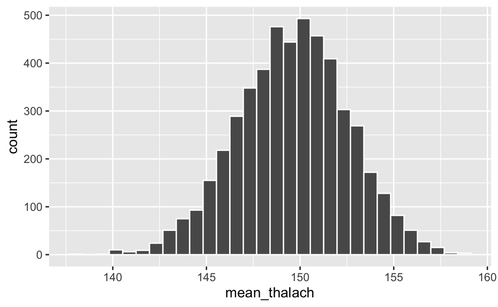

```r
pe_50_5000 %>%
  ggplot() +
  aes(x = mean_thalach) +
  geom_histogram(col = "white")
```

# Prop Exang Sampling Distribution

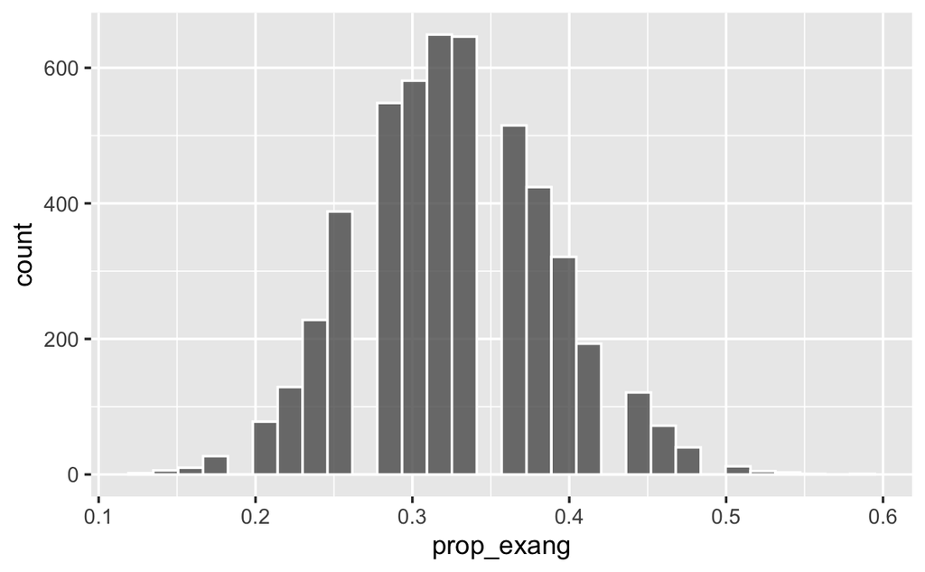

```r
pe_50_5000 %>%
  ggplot() +
  aes(x = prop_exang) +
  geom_histogram(col = "white", alpha = 0.8)
```

Obtain standard errors of the sampling distribution of mean_thalach and prop_exang directly as the standard deviations of the sampling distributions held in rep_sample_50

# Standard Error

Standard error is the sd of the sampling distribution

| se_thalach | se_exang |
| --- | --- |
| 2.952875 | 0.06136065 |

Repeat steps 7. and 9. (omitting step 8.) once more with samples of size 100-patients, and again with samples of size 200-patients. How do the standard errors of mean_thalach and prop_exang change as sample size increases? Does the uncertainty in the calculated statistics increase or decrease as sample size increases? [Hint - it’s OK to copy, paste and alter code to do this!]

```r
sample_100_5000 <- heart %>%
  rep_sample_n(size = 100, reps = 5000, replace = F)

pe_100_5000 <- sample_100_5000 %>%
  ungroup() %>%
  group_by(replicate) %>%
  summarise(mean_thalach = mean(thalach),
            prop_exang = mean(exang == 1))
```

# Standard Error

| se_thalach | se_exang |
| --- | --- |
| 1.891851 | 0.03901407 |

```r
sample_200_5000 <- heart %>%
  rep_sample_n(size = 200, reps = 5000, replace = F)

pe_200_5000 <- sample_200_5000 %>%
  ungroup() %>%
  group_by(replicate) %>%
  summarise(mean_thalach = mean(thalach),
            prop_exang = mean(exang == 1))
```

# Standard Error

| se_thalach | se_exang |
| --- | --- |
| 0.9526795 | 0.01960771 |

```r
se_50_5000
```

| se_thalach | se_exang |
| --- | --- |
| 2.952875 | 0.06136065 |

```r
se_100_5000
```

| se_thalach | se_exang |
| --- | --- |
| 1.891851 | 0.03901407 |

```r
se_200_5000
```

| se_thalach | se_exang |
| --- | --- |
| 0.9526795 | 0.01960771 |

Standard error decreases as sample size increases. Or certainty increases as sample size increases.